# Workflow RNA-seq Analysis

Analysis of count matrix data

Mariana Mescouto Lopes

2026

## Overview

This workflow demonstrates a basic RNA-seq analysis pipeline.  
To run the analysis, update the file paths according to your local environment.

This workflow performs: - Data preprocessing - Differential expression analysis - Data visualization - Functional enrichment analysis (GSEA)

# 1. Packges

To install packages, use: install.packages(“package_name”)

Then load them using: library(package_name)

```r
suppressPackageStartupMessages({
  # Diferential analysis
  library(DESeq2)
  library(edgeR)
  library(limma)
  library(fdrtool)

  # Data manipulation
  library(dplyr)
  library(readr)
  library(readxl)
  library(tibble)

  # Visualization
  library(ggplot2)
  library(pheatmap)
  library(ggrepel)
  library(RColorBrewer)
  library(corrplot)
  library(plotly)

  # Functional analysis
  library(fgsea)
  library(biomaRt)
  library(here)

  # Tables
  library(DT)
  library(kableExtra)
})
```

Necessary for GSEA

# 2. Data preprocessing

Load count matrix and sample metadata

```r
setwd("~/Library/CloudStorage/OneDrive-Personal/Documentos/GitHub")
df <- read_delim("rnaseq_data.csv", delim = ";", show_col_types = FALSE)
metadata <- read_excel("samples.xlsx")

# Dataset information
cat(sprintf("Raw dataset: %d genes × %d columns\n", nrow(df), ncol(df)))
```

```
## Raw dataset: 35670 genes × 19 columns
```

```r
cat(sprintf("Metadata: %d samples\n", nrow(metadata)))
```

```
## Metadata: 18 samples
```

## Sample selection and gene formatting

```r
ctrl_samples <- grep("CON_", colnames(df), value = TRUE)
treat_samples <- grep("BET_", colnames(df), value = TRUE)

cat(sprintf("Samples: %d control + %d treated\n",
            length(ctrl_samples), length(treat_samples)))
```

```
## Samples: 9 control + 9 treated
```

```r
# Set gene IDs as row names
genes <- df$gene
df <- as.matrix(df[, c(ctrl_samples, treat_samples)])
rownames(df) <- genes
```

## Filtering low expressed genes

Criteria: keep genes with ≥5 counts in at least 6 samples

```r
filter_mask <- rowSums(df >= 5) >= 6
expr_genes <- genes[filter_mask]
df_filtered <- df[filter_mask, ]

cat(sprintf("Initial number of genes: %d\n", nrow(df)))
```

```
## Initial number of genes: 35670
```

```r
cat(sprintf("Filtered dataset: %d genes (%.1f%% retained)\n",
            nrow(df_filtered),
            100 * nrow(df_filtered) / nrow(df)))
```

```
## Filtered dataset: 5764 genes (16.2% retained)
```

## Metadata alignment

```r
metadata_filtered <- metadata %>%
  filter(ID %in% c(ctrl_samples, treat_samples)) %>%
  arrange(match(ID, c(ctrl_samples, treat_samples)))
```

Save filtered data

```r
write_csv(as.data.frame(df_filtered), "~/Library/CloudStorage/OneDrive-Personal/Documentos/GitHub/results/filtered_data.csv")
```

# 3. Exploratory Data Analysis

## Data distribution

Evaluate data quality and filtering criteria

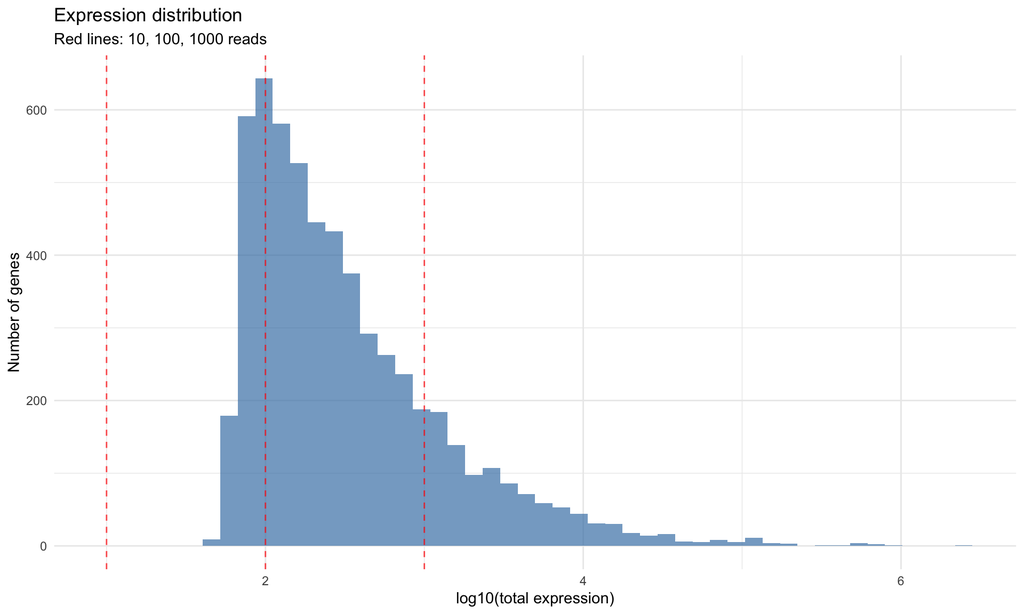

```r
total_expression <- rowSums(df_filtered)

p_dist <- ggplot(data.frame(total_expression),
                 aes(x = log10(total_expression + 1))) +
  geom_histogram(bins = 50, fill = "steelblue", alpha = 0.7) +
  geom_vline(xintercept = log10(c(10, 100, 1000)),
             linetype = "dashed", color = "red", alpha = 0.7) +
  labs(
    title = "Expression distribution",
    subtitle = "Red lines: 10, 100, 1000 reads",
    x = "log10(total expression)",
    y = "Number of genes"
  ) +
  theme_minimal()

print(p_dist)
```

Most genes show low expression levels, which is expected in RNA-seq data. The filtering step removes lowly expressed genes, reducing noise and improving downstream analysis.

Save plot

```r
ggsave("~/Library/CloudStorage/OneDrive-Personal/Documentos/GitHub/results/figures/histogram.png", p_dist, width = 10, height = 8)
```

## PCA

Explore sample variability and identify potential clustering patterns

1. Normalization

```r
df_log <- log2(df_filtered + 1)
```

2. PCA computation

```r
pca <- prcomp(t(df_log), scale. = TRUE)
pca_data <- data.frame(pca$x)

pca_data$sample <- rownames(pca_data)
pca_data$group <- ifelse(grepl("CON_", pca_data$sample), "Control", "Treated")
```

3. PCA plot

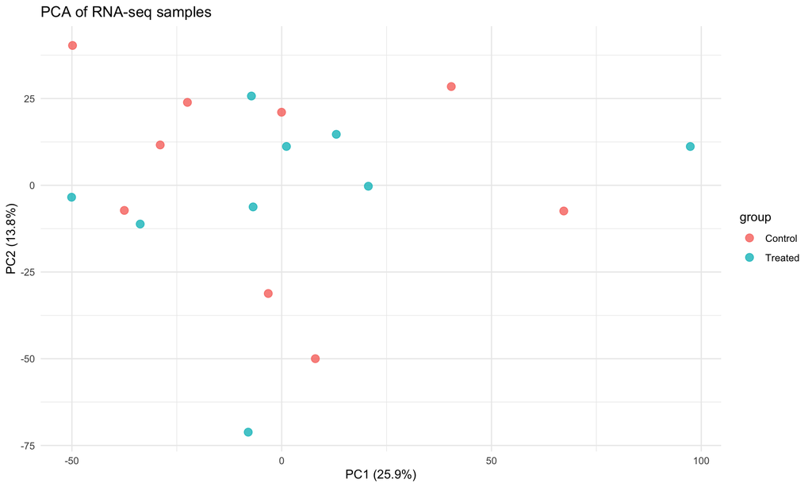

```r
p_pca <- ggplot(pca_data, aes(PC1, PC2, color = group)) +
  geom_point(size = 3, alpha = 0.8) +
  labs(
    title = "PCA of RNA-seq samples",
    x = paste0("PC1 (", round(summary(pca)$importance[2,1]*100, 1), "%)"),
    y = paste0("PC2 (", round(summary(pca)$importance[2,2]*100, 1), "%)")
  ) +
  theme_minimal()

print(p_pca)
```

PCA revealed no clear separation between control and treated samples, suggesting that the treatment effect is relatively subtle compared to the overall variability in the dataset.

This may reflect either a mild biological response or inherent variability between samples.

Save PCA

```r
  ggsave("~/Library/CloudStorage/OneDrive-Personal/Documentos/GitHub/results/figures/PCA.png", p_pca, width = 10, height = 8)
```

## Hierarchical clustering

Assess sample similarity.

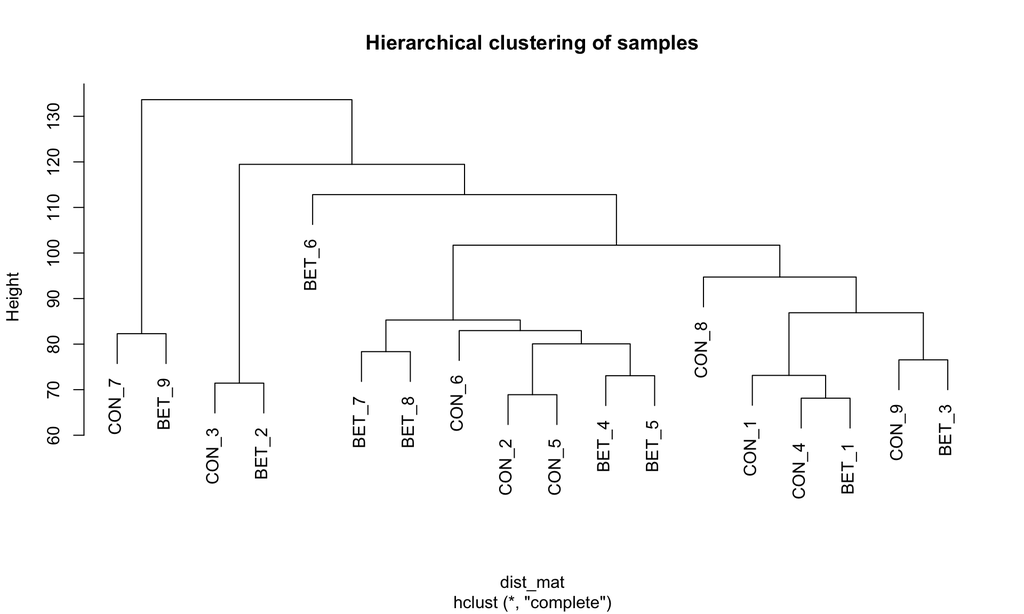

```r
dist_mat <- dist(t(df_log))
hc <- hclust(dist_mat)

p_hc <- plot(hc, main = "Hierarchical clustering of samples")
```

Hierarchical clustering did not fully separate samples by condition, further supporting the observation that the treatment effect is modest.

Some samples cluster independently of their group, indicating variability within conditions.

Save dendrogram

```r
  ggsave("~/Library/CloudStorage/OneDrive-Personal/Documentos/GitHub/results/figures/dendrogram.png", p_hc, width = 10, height = 8)
```

## Heatmap

Top 10 most highly expressed genes

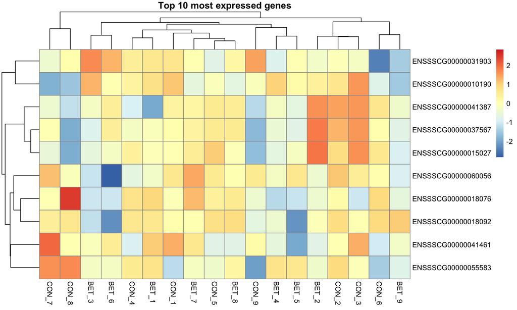

```r
top_genes <- head(order(rowMeans(df_log), decreasing = TRUE), 10)

p_heatmap <- pheatmap(df_log[top_genes, ],
         scale = "row",
         main = "Top 10 most expressed genes")
```

The heatmap of highly expressed genes shows no strong clustering by condition, suggesting that the most abundant genes are not strongly affected by the treatment.

This is consistent with the PCA and clustering results.

Save dendrogram

```r
  ggsave("~/Library/CloudStorage/OneDrive-Personal/Documentos/GitHub/results/figures/heatmap.png", p_heatmap, width = 10, height = 8)
```

# 4. Differential analysis

Organize metadata

```r
coldata <- DataFrame(
  treatment = factor(metadata_filtered$TRAT),
  ID = metadata_filtered$Identificação,
  row.names = metadata_filtered$ID
)

#Check order
if (!identical(colnames(df), rownames(coldata))) {
  cat("Samples...\n")
  coldata <- coldata[colnames(df_filtered), ]
}
```

DESeq2

```r
dds <- DESeqDataSetFromMatrix(
  countData = df_filtered,
  colData = coldata,
  design = ~ treatment
)

dds <- DESeq(dds)
```

Results

```r
res <- results(dds, contrast = c("treatment", "BET", "CON"))

res_summary <- data.frame(
  Info = c("p-adj < 0.05", "p-adj < 0.10", "p-adj < 0.20"),
  Value = c(
    sum(res$padj < 0.05, na.rm = TRUE),
    sum(res$padj < 0.10, na.rm = TRUE),
    sum(res$padj < 0.20, na.rm = TRUE)
  )
)

kable(res_summary) %>% kable_styling()
```

| Info | Value |
| --- | --- |
| p-adj < 0.05 | 0 |
| p-adj < 0.10 | 0 |
| p-adj < 0.20 | 0 |

Save results

```r
write.table(as.data.frame(res), "~/Library/CloudStorage/OneDrive-Personal/Documentos/GitHub/results/tables/deseq_results.tsv", sep="\t", quote=F, row.names=F)
```

# 5. Pathway analysis

Necessary inputs for GSEA

```r
unique_genes <- unique(rownames(df_filtered))

#ensembl
mart <- useEnsembl("genes",
                   dataset = "sscrofa_gene_ensembl",
                   mirror = "useast")

#annotation table
annotation_table <- getBM(
  attributes = c("ensembl_gene_id", "external_gene_name", "description", "gene_biotype"),
  filters = "ensembl_gene_id",
  values = unique_genes,
  mart = mart
)

#Genes annotated data
# First, convert matrix to data frame
df_filtered_table <- df_filtered %>%
  as.data.frame() %>%
  rownames_to_column(var = "gene")

# joing with annotation data
GenesAnnot_df <- left_join(df_filtered_table, annotation_table,
                     by = c("gene" = "ensembl_gene_id"))
```

Input Deseq2 results

```r
#Deseq2 data
deseq2_df <- as.data.frame(res) %>%
  rownames_to_column(var = "ensembl_gene_id")

#Join annotation + deseq2
DegsAnnot_df <- deseq2_df %>%
  left_join(
    annotation_table %>% dplyr::select(ensembl_gene_id, external_gene_name),
    by = "ensembl_gene_id"
  ) %>%
  column_to_rownames(var = "ensembl_gene_id")

#Reorder according with stat
ord <- order(DegsAnnot_df$stat, decreasing = TRUE)

# extract genes
genesOrd <- DegsAnnot_df$stat[ord]

# Eextract gene names
names(genesOrd) <- DegsAnnot_df$external_gene_name[ord]

# exclude NAs
genesOrd <- genesOrd[!is.na(names(genesOrd))]
genesOrd <- genesOrd[names(genesOrd) != ""]
```

Load gene sets

```r
# Use here() to point to the file in the project root
kegg_file <- here("KEGG_2021_Human.txt")

# Now call the function
pathways <- processDB(kegg_file)
```

Run GSEA

```r
#Parameters
minSize <- 15
maxSize <- 500

fgseaRes <- fgsea(pathways, genesOrd, minSize = minSize, maxSize = maxSize)

fgseaRes_df <- as.data.frame(fgseaRes)
fgseaRes_df$leadingEdge <- sapply(fgseaRes$leadingEdge, function(x) paste(x, collapse = ","))

# Top enriched pathways
topPathways <- fgseaRes[order(padj)][head(10)]
print(topPathways)
```

```
##                             pathway       pval      padj   log2err         ES
##                              <char>      <num>     <num>     <num>      <num>
## 1: Protein digestion and absorption 0.01578314 0.3424941 0.3524879 -0.5109192
##          NES  size                                      leadingEdge
##        <num> <int>                                           <list>
## 1: -1.600202    24 KCNE3,COL4A1,COL3A1,COL1A2,ATP1B4,SLC3A1,...[12]
```

GSEA bar plot

```r
# Filtering for significance based on GSEA standard (padj < 0.25)
gsea_significant <- fgseaRes_df %>%
  filter(padj < 0.25) %>%
  arrange(padj) %>%
  mutate(Regulation = ifelse(NES > 0, "Up-regulated", "Down-regulated"))

cat(sprintf("✅ Significant pathways found: %d\n", nrow(gsea_significant)))
```

```
## ✅ Significant pathways found: 9
```

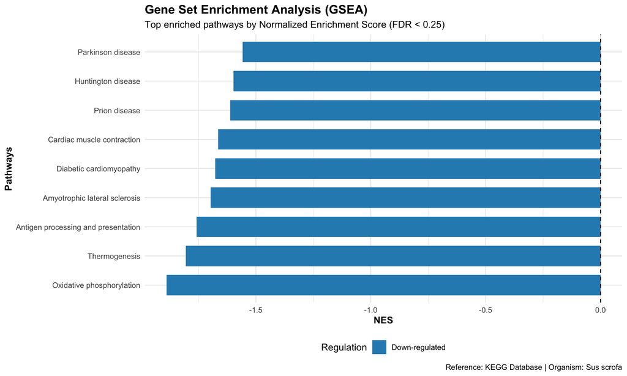

```r
if (nrow(gsea_significant) > 0) {

  # Plotting the Enrichment Scores (NES)
  # Showing top 20 pathways for clarity
  p_gsea_final <- ggplot(head(gsea_significant, 20), aes(x = reorder(pathway, NES), y = NES)) +
    geom_col(aes(fill = Regulation), width = 0.7) +
    coord_flip() +
    scale_fill_manual(values = c("Up-regulated" = "#e34a33", "Down-regulated" = "#2b8cbe")) +
    geom_hline(yintercept = 0, linetype = "dashed", color = "black") +
    labs(
      title = "Gene Set Enrichment Analysis (GSEA)",
      subtitle = "Top enriched pathways by Normalized Enrichment Score (FDR < 0.25)",
      x = "Pathways",
      y = "NES",
      caption = "Reference: KEGG Database | Organism: Sus scrofa"
    ) +
    theme_minimal() +
    theme(
      plot.title = element_text(face = "bold", size = 14),
      axis.title = element_text(face = "bold"),
      legend.position = "bottom"
    )

  print(p_gsea_final)
}
```

Save plot

```r
write.table(gsea_significant, "~/Library/CloudStorage/OneDrive-Personal/Documentos/GitHub/results/gsea/gsea_significant_results.tsv", sep="\t", quote=F, row.names=F)
  ggsave("~/Library/CloudStorage/OneDrive-Personal/Documentos/GitHub/results/gsea/gsea_plot.png", p_gsea_final, width = 10, height = 8)
```